# ARF Conditional Density Dashboard

```r
library(tidyverse)
library(glue)
library(DT)

source("01_config_and_dgp.R")
source("plot_helpers.R")
psi_registry <- readRDS("results/psi_registry.rds")
```

# DGPs

Here’s a DGP with a distinct distribution for each group:

### What each group stress-tests in ARF

| Group | Distribution | ARF challenge |
| --- | --- | --- |
| female/1 | Bimodal Gaussian | Valley between modes on linear scale |
| male/1 | Bimodal Log Normal | Quite difficult |
| female/2 | Power law (1/x²) | Extreme skew, mass near lower bound |
| male/2 | Uniform | Flat density — ARF seems to really struggle here |
| female/3 | Gamma | Moderate skew, unimodal — ARF’s 2nd easiest case |
| male/3 | Spike + gamma tail | very different scales |

# Overview of Experiments

Global Parameters:

- sample size of simulation, N = 3000
- extra columns: 0

The following shows a total of 48 experiments which are parameter sweep combinations of:

- **mtry** (3 levels): 1, 2, 3
- **finite_bounds** (2 levels): local, no
- **family** (2 levels): truncnorm, unif
- **num_trees** (2 levels): 100, 500
- **min_node_size** (2 levels): 20, 100

```r
psi_registry <- psi_registry |> arrange(meanIAE)


overview_tbl <- psi_registry |>
  select(
    mtry,
    family,
    finite_bounds,
    num_trees,
    min_node_size,
    meanIAE
  )
overview_tbl$meanIAE = round(overview_tbl$meanIAE,3)

cat("\n",file="Log.txt")

#knitr::kable(overview_tbl)
DT::datatable(overview_tbl)
```

|  | mtry | family | finite_bounds | num_trees | min_node_size | meanIAE |
| --- | --- | --- | --- | --- | --- | --- |
| 1 | 3 | unif | local | 500 | 20 | 0.167 |
| 2 | 3 | unif | no | 500 | 20 | 0.167 |
| 3 | 3 | unif | local | 100 | 20 | 0.168 |
| 4 | 3 | unif | no | 100 | 20 | 0.168 |
| 5 | 3 | truncnorm | local | 100 | 20 | 0.185 |
| 6 | 3 | truncnorm | no | 100 | 20 | 0.186 |
| 7 | 3 | truncnorm | local | 500 | 20 | 0.187 |
| 8 | 3 | truncnorm | no | 500 | 20 | 0.187 |
| 9 | 2 | truncnorm | local | 500 | 20 | 0.208 |
| 10 | 2 | truncnorm | no | 500 | 20 | 0.214 |

[output cut: 38 more lines]

# All Experiments

```r
for(i in seq_len(nrow(psi_registry))) {
#for(i in 1:4) {

  row <- psi_registry[i, ]

  grid_file <- glue(
    "results/grids/grid_mtry{row$mtry}_ntree{row$num_trees}_nodeSize{row$min_node_size}_seed{row$seed}_{row$family}_{row$finite_bounds}.rds"
  )

  metric_file <- glue(
    "results/metrics/metric_mtry{row$mtry}_ntree{row$num_trees}_nodeSize{row$min_node_size}_seed{row$seed}_{row$family}_{row$finite_bounds}.rds"
  )
  arf_file <- glue(
    "results/arf/arf_mtry{row$mtry}_ntree{row$num_trees}_nodeSize{row$min_node_size}_seed{row$seed}.rds"
  )

  psi_file <- glue(
    "results/psi/psi_mtry{row$mtry}_ntree{row$num_trees}_nodeSize{row$min_node_size}_seed{row$seed}_{row$family}_{row$finite_bounds}.rds"
  )

  arf_obj <- readRDS(arf_file)
  psi_obj <- readRDS(psi_file)
  grid <- readRDS(grid_file)
  metrics <- readRDS(metric_file)

  synData_file <- glue(
      "results/synData/synX_mtry{row$mtry}_ntree{row$num_trees}_nodeSize{row$min_node_size}_seed{row$seed}_{row$family}_{row$finite_bounds}.rds")

  if (!file.exists(synData_file)){
    cat("generating synthetic data", synData_file,"\n",file="Log.txt", append = T)
    synData = genHistData(psi_obj,arf_obj)
    saveRDS(synData, synData_file)
  }



  cat("\n\n")
  cat("## Experiment ", i, "\n\n")

  cat(
    glue(
      "- **mtry**: {row$mtry}\n",
      "- **family**: {row$family}\n",
      "- **finite_bounds**: {row$finite_bounds}\n",
      "- **num_trees**: {row$num_trees}\n",
      "- **min_node_size**: {row$min_node_size}\n",
      "- **IAE**: {round(row$medianIAE,3)}\n\n"
      #"- **seed**: {row$seed}\n\n"
    )
  )

  gg_file <- glue(
    "results/plots/gg_mtry{row$mtry}_ntree{row$num_trees}_nodeSize{row$min_node_size}_seed{row$seed}_{row$family}_{row$finite_bounds}.rds"
  )

  #if (!file.exists(gg_file)) {
  if (1){
    cat("generating plots", gg_file,"\n",file="Log.txt", append = T)
    p1 <- plot_density_histogram(
      grid = grid,
      params = row,
      TRUE
    )
    synData = readRDS(synData_file)
    synData$source = factor(synData$source, levels = c("synthetic", "original"))
    p2 = plotHists(synData, TRUE)
    g = list(lik=p1, hist =p2)

    saveRDS(g, gg_file)
  } else {
    g = readRDS(gg_file)
    p1 = g[[1]]
    p2 = g[[2]]
  }

  print(p1+ scale_y_sqrt())

  print(p2+ scale_y_sqrt())


  cat("\n\n---\n\n")
}
```

## Experiment 1

- **mtry**: 3
- **family**: unif
- **finite_bounds**: local
- **num_trees**: 500
- **min_node_size**: 20
- **IAE**: 0.169

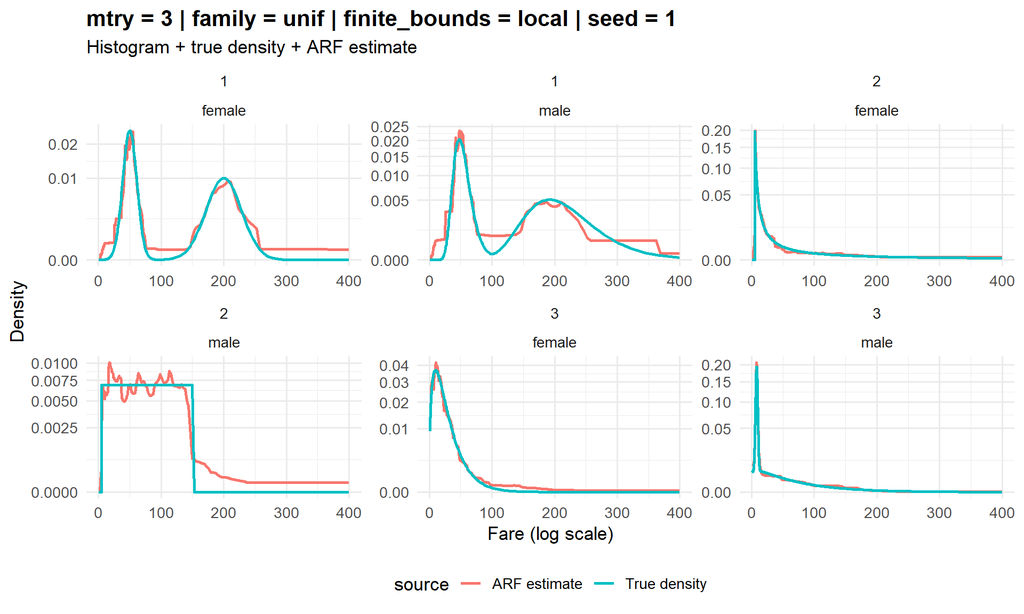

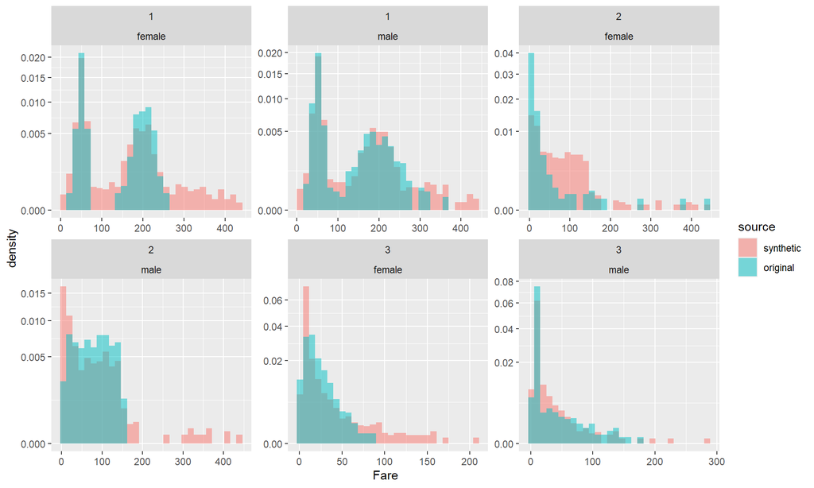

## Experiment 2

- **mtry**: 3
- **family**: unif
- **finite_bounds**: no
- **num_trees**: 500
- **min_node_size**: 20
- **IAE**: 0.169

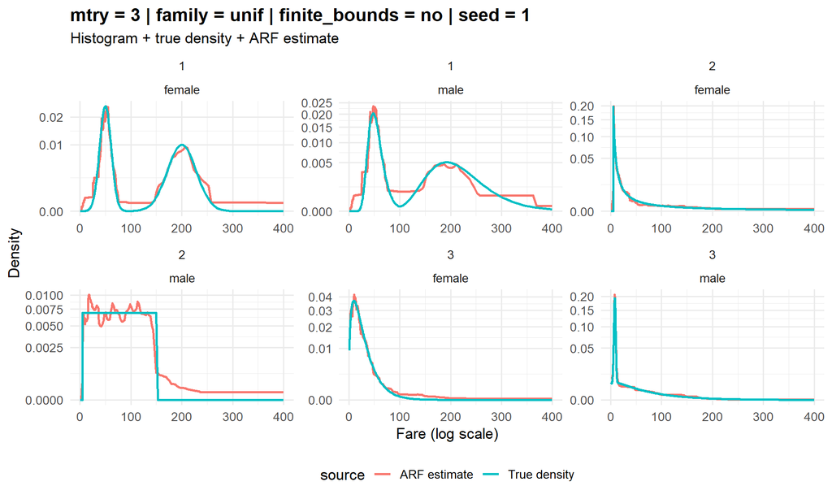

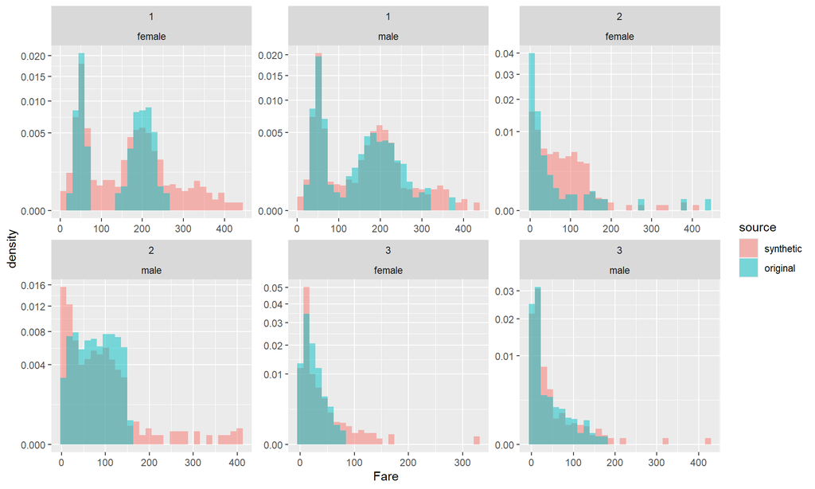

## Experiment 3

- **mtry**: 3
- **family**: unif
- **finite_bounds**: local
- **num_trees**: 100
- **min_node_size**: 20
- **IAE**: 0.166

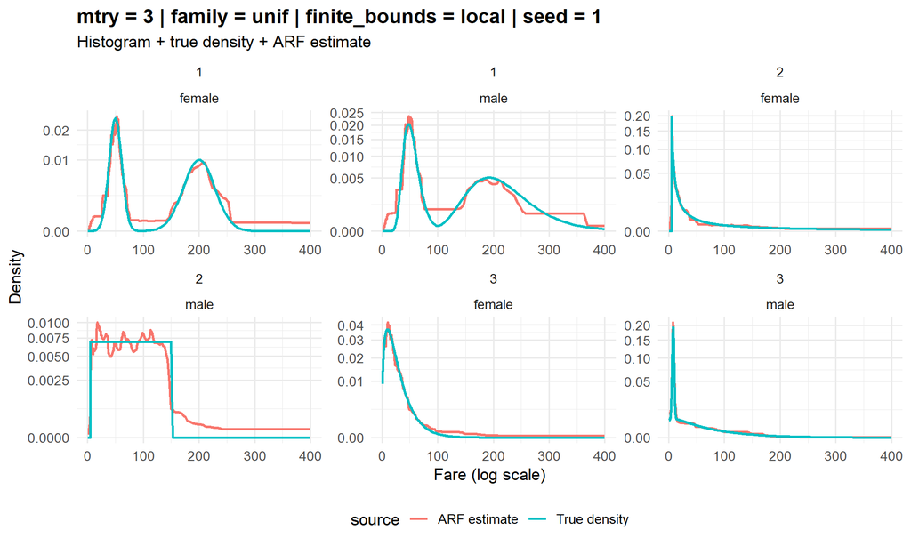

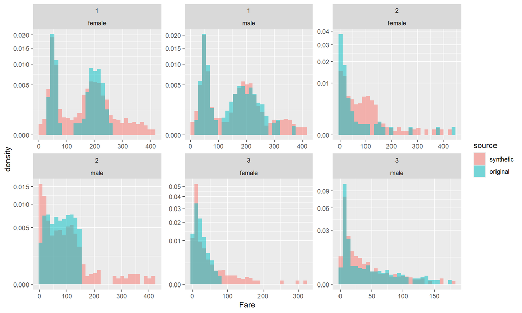

## Experiment 4

- **mtry**: 3
- **family**: unif
- **finite_bounds**: no
- **num_trees**: 100
- **min_node_size**: 20
- **IAE**: 0.166

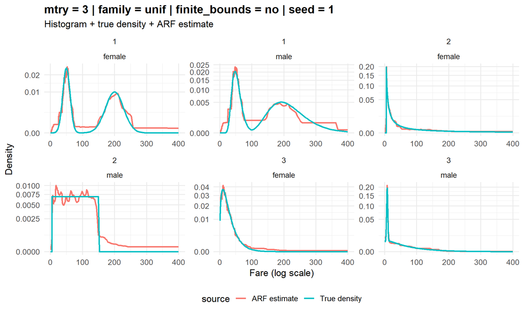

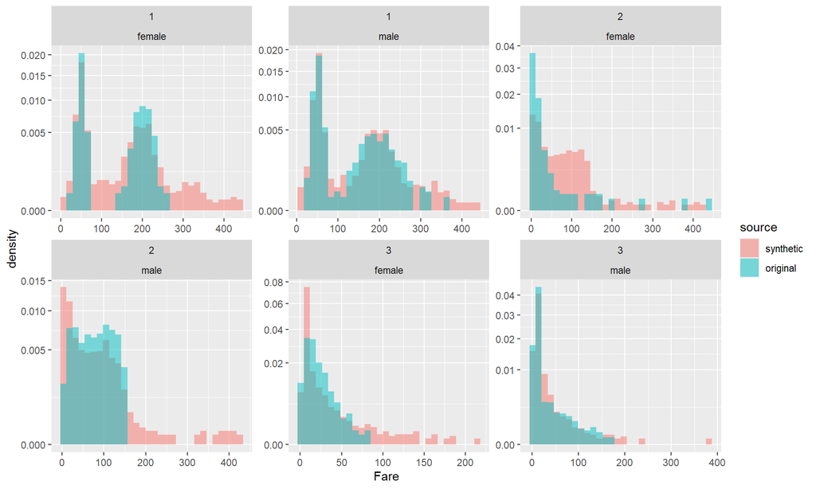

## Experiment 5

- **mtry**: 3
- **family**: truncnorm
- **finite_bounds**: local
- **num_trees**: 100
- **min_node_size**: 20
- **IAE**: 0.19

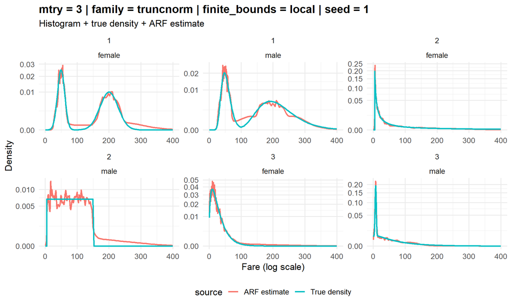

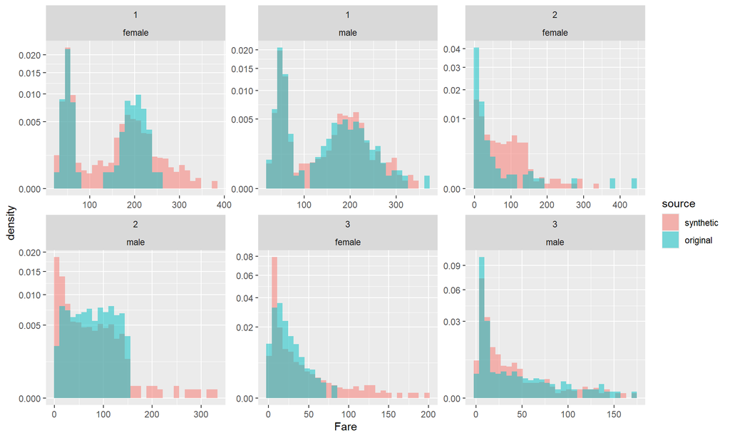

## Experiment 6

- **mtry**: 3
- **family**: truncnorm
- **finite_bounds**: no
- **num_trees**: 100
- **min_node_size**: 20
- **IAE**: 0.191

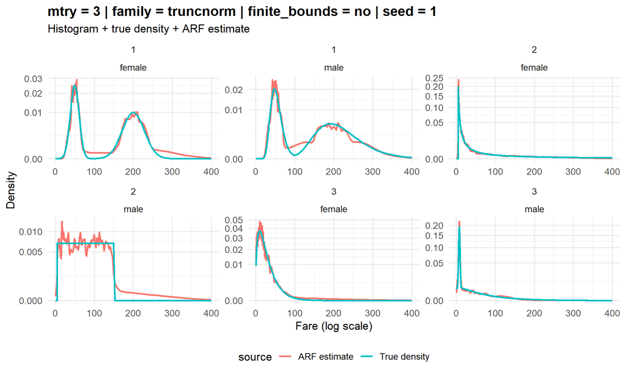

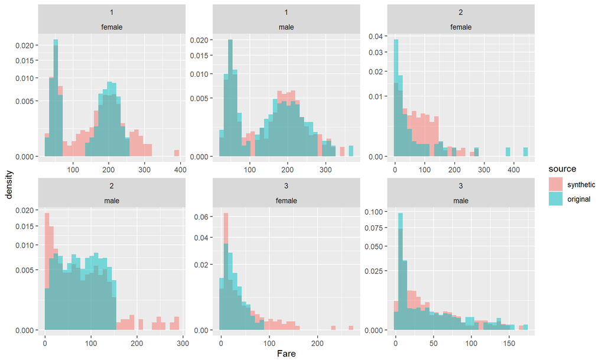

## Experiment 7

- **mtry**: 3
- **family**: truncnorm
- **finite_bounds**: local
- **num_trees**: 500
- **min_node_size**: 20
- **IAE**: 0.192

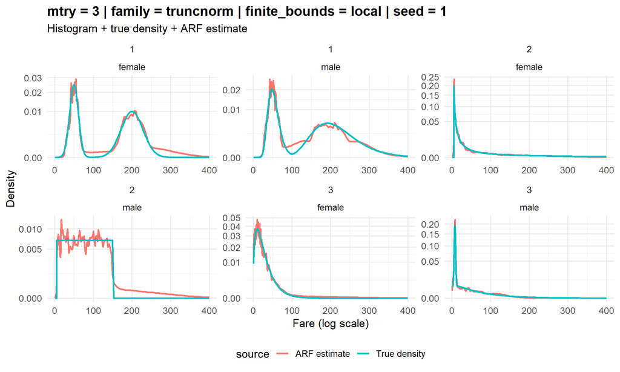

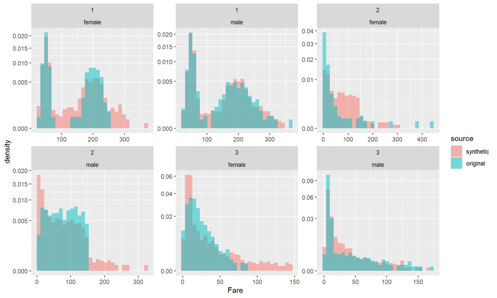

## Experiment 8

- **mtry**: 3
- **family**: truncnorm
- **finite_bounds**: no
- **num_trees**: 500
- **min_node_size**: 20
- **IAE**: 0.193

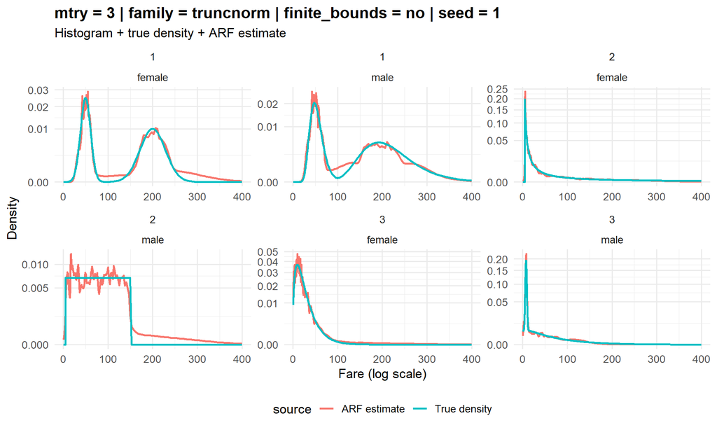

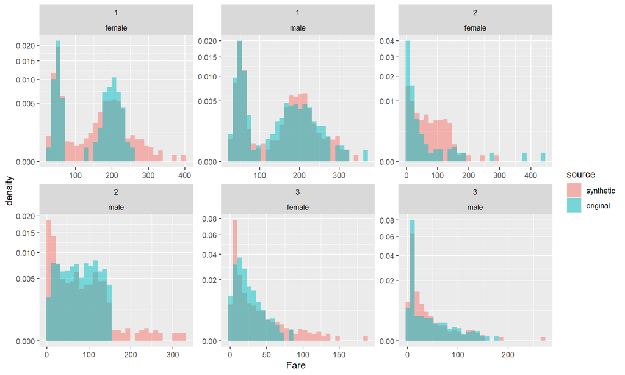

## Experiment 9

- **mtry**: 2
- **family**: truncnorm
- **finite_bounds**: local
- **num_trees**: 500
- **min_node_size**: 20
- **IAE**: 0.205

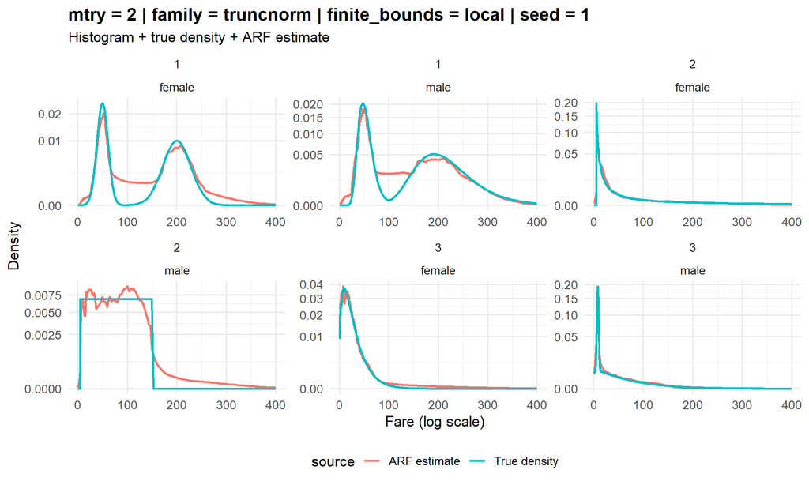

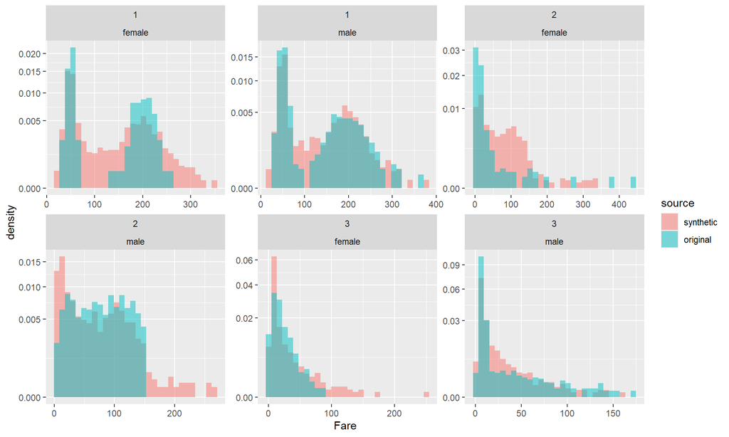

## Experiment 10

- **mtry**: 2
- **family**: truncnorm
- **finite_bounds**: no
- **num_trees**: 500
- **min_node_size**: 20
- **IAE**: 0.215

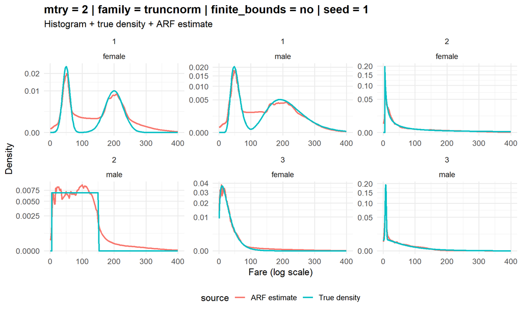

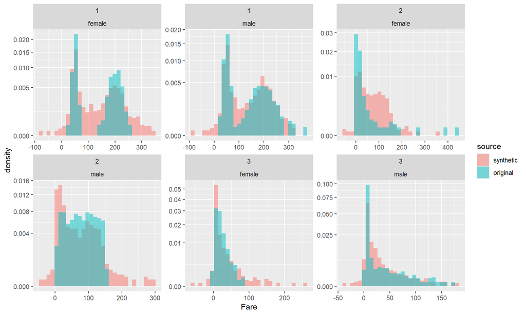

## Experiment 11

- **mtry**: 2
- **family**: truncnorm
- **finite_bounds**: local
- **num_trees**: 100
- **min_node_size**: 20
- **IAE**: 0.214

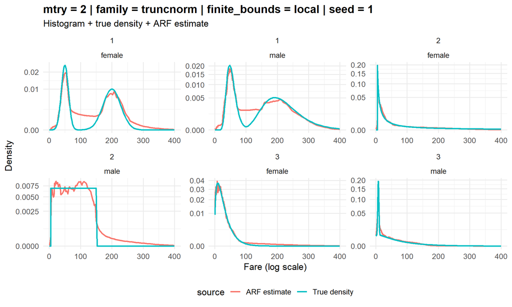

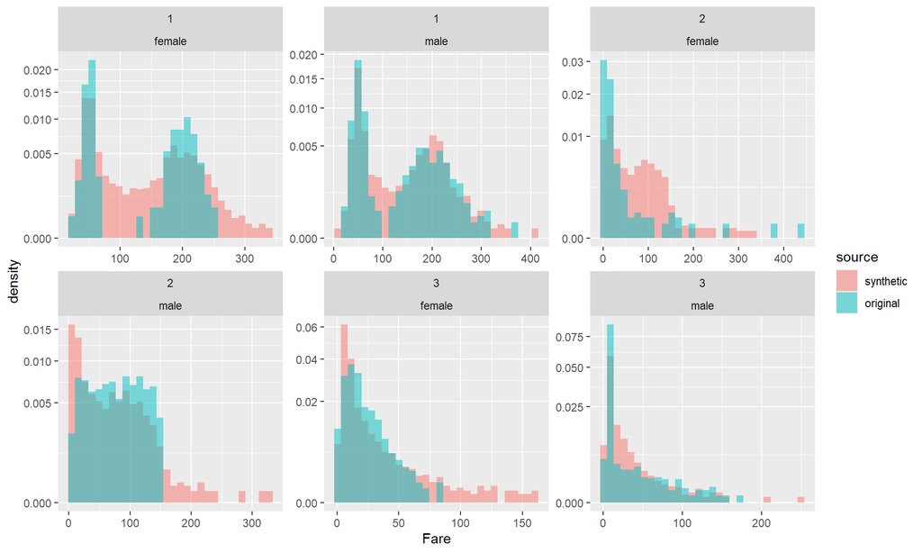

## Experiment 12

- **mtry**: 2
- **family**: truncnorm
- **finite_bounds**: no
- **num_trees**: 100
- **min_node_size**: 20
- **IAE**: 0.226

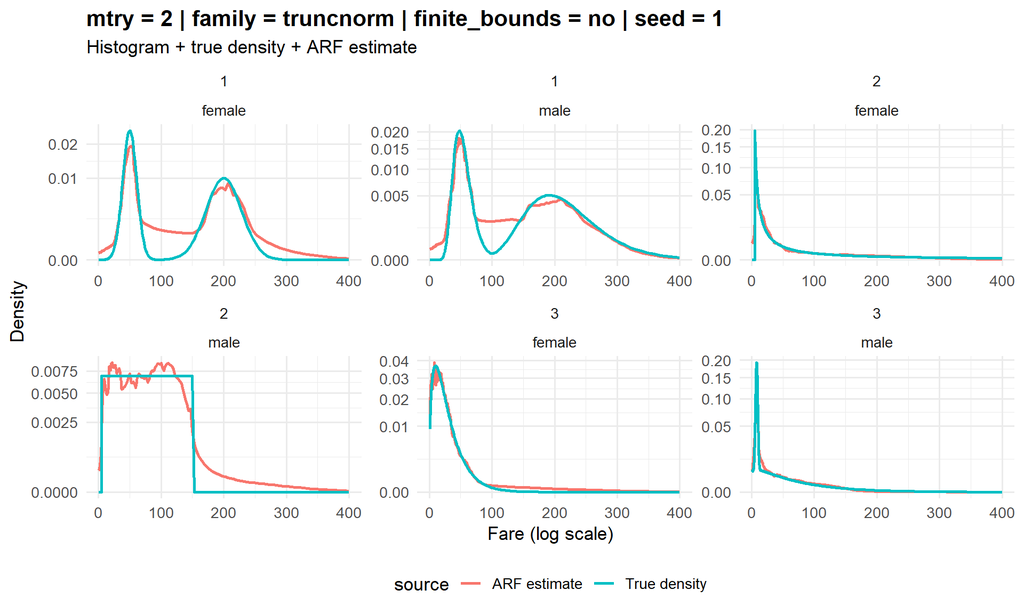

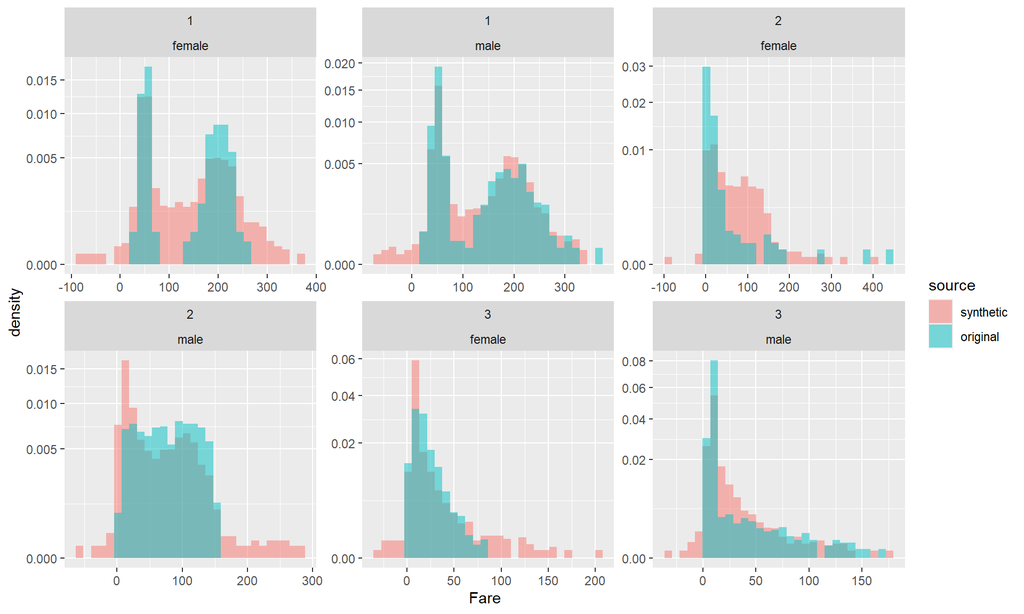

## Experiment 13

- **mtry**: 3
- **family**: truncnorm
- **finite_bounds**: local
- **num_trees**: 500
- **min_node_size**: 100
- **IAE**: 0.268

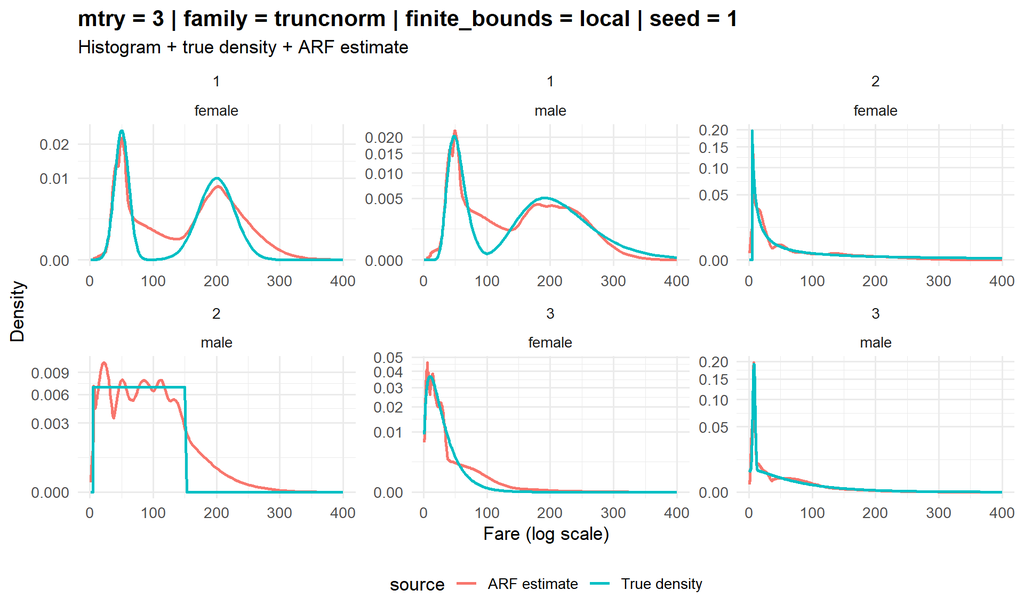

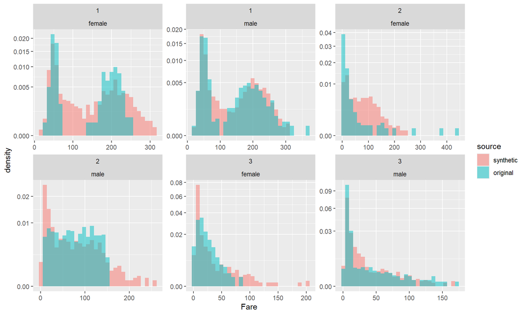

## Experiment 14

- **mtry**: 3
- **family**: truncnorm
- **finite_bounds**: local
- **num_trees**: 100
- **min_node_size**: 100
- **IAE**: 0.268

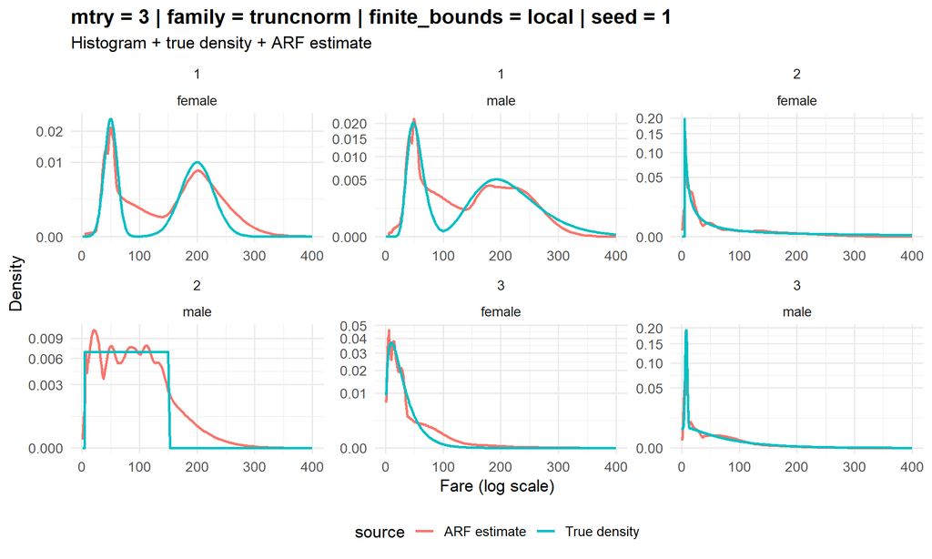

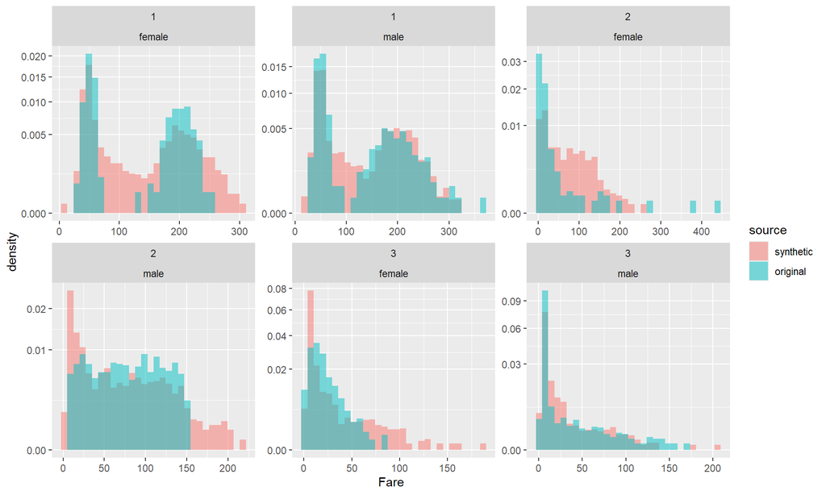

## Experiment 15

- **mtry**: 3
- **family**: truncnorm
- **finite_bounds**: no
- **num_trees**: 500
- **min_node_size**: 100
- **IAE**: 0.269

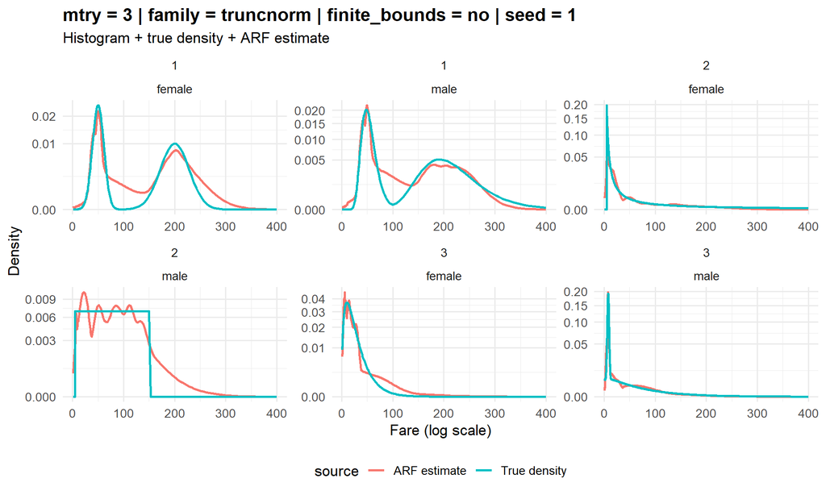

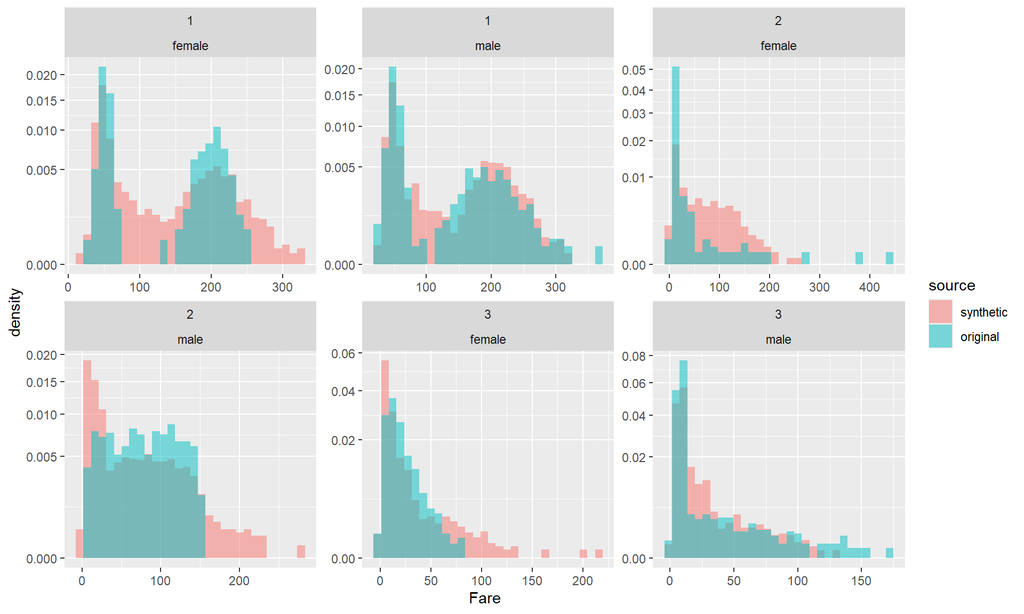

## Experiment 16

- **mtry**: 3
- **family**: truncnorm
- **finite_bounds**: no
- **num_trees**: 100
- **min_node_size**: 100
- **IAE**: 0.273

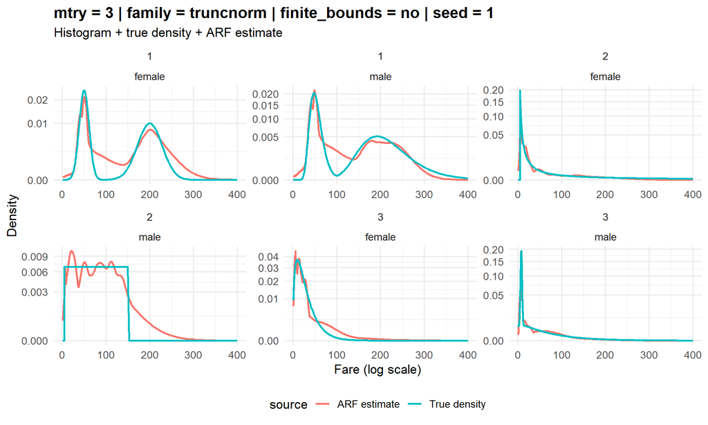

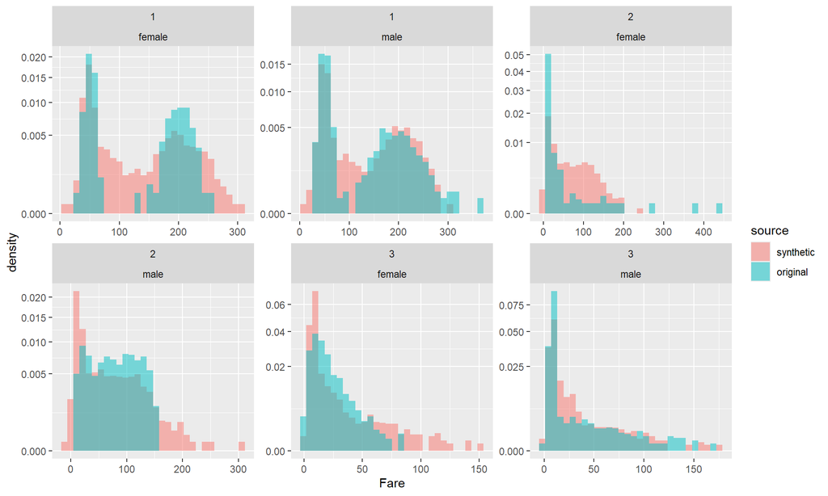